# Facial Recognition (Eigenfaces)

**Objective:** Given a new image, find the closest matching image in a database of images.

**Data:** Our database of images consists of 153 different faces formatted as JPEG images (200x180 pixels). The images are black and white.

```python
# Begin by importing the necessary modules
import numpy as np
from scipy import linalg as la
from os import walk
from scipy.ndimage import imread
from matplotlib import pyplot as plt
import matplotlib.cm as cm
import random
%matplotlib inline
```

### Create the Database

```python
def getFaces(path='./faces94'):
    """Traverse the directory specified by 'path' and return an array containing
    one column vector per subdirectory.
    """
    # Traverse the directory and get one image per subdirectory
    faces = []
    for (dirpath, dirnames, filenames) in walk(path):
        for f in filenames:
            if f[-3:]=="jpg": # only get jpg images
                # load image, convert to grayscale, flatten into vector
                face = imread(dirpath+"/"+f).mean(axis=2).ravel()
                faces.append(face)
                break
    # put all the face vectors column-wise into a matrix
    return np.array(faces).T
```

The class *FacialRec* will use the *getFaces( )* function above and use the data to create an "average" face. Also, a copy will be made for each image with the average face subtracted from the original image which helps us determine the uniqueness of a face which we call an *eigenface*. This class also contains a method for finding the closest match to a certain image by searching through these eigenfaces.

```python
class FacialRec:
    #########Members#########
    # F, mu, Fbar, and U
    #########################
    def __init__(self,path):
        self.initFaces(path)
        self.initMeanImage()
        self.initDifferences()
        self.initEigenfaces()

    def initFaces(self,path):
        self.F = getFaces(path)
    def initMeanImage(self):
        self.mu = np.mean(self.F,axis=1)
    def initDifferences(self):
        self.Fbar = self.F - np.vstack(self.mu)
    def initEigenfaces(self):
        self.U, s, Vt = la.svd(self.Fbar,full_matrices=False)
    def project(self, A, s=38):
        U_s = self.U[:,:s]
        return np.dot(U_s.T,A)
    def findNearest(self, image, s=38):
        Fhat = self.project(self.Fbar,s) # this performs U^t * (f-mu)
        gbar = image - np.vstack(self.mu) # image is already flattened
        ghat = self.project(gbar,s)
        normed_vec = np.linalg.norm((Fhat - ghat),axis=0)
        return np.argmin(normed_vec)
```

The following *show( )* function displays a given image.

```python
def show(im, w=200, h=180):
    """Plot the flattened grayscale image 'im' of width 'w' and height 'h'."""
    plt.imshow(im.reshape((w,h)), cmap=cm.Greys_r)
    plt.show()
```

For convenience, the following function **show2** will show two images side-by-side.

```python
def show2(test_image, result, w=200, h=180):
    """Convenience function for plotting two flattened grayscale images of
    the specified width and height side by side
    """
    plt.subplot(121)
    plt.title("Inputed Image")
    plt.imshow(test_image.reshape((w,h)), cmap=cm.Greys_r)
    plt.axis("off")
    plt.subplot(122)
    plt.title("Closest Match")
    plt.imshow(result.reshape((w,h)), cmap=cm.Greys_r)
    plt.axis("off")
    plt.show()
```

### Performing a Mean Shift on the Faces

To accentuate the unique features of each of the faces, we will perform a mean shift. First, we must calculate the mean face using the *FacialRec* class. The mean face is plotted below.

#### Calculate the Mean Face

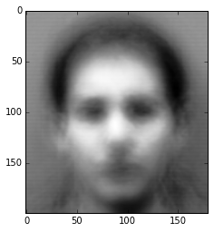

```python
facialrec = FacialRec('./faces94')
show(facialrec.mu)
```

Below we compare the original image with a mean-shifted copy of the same face.

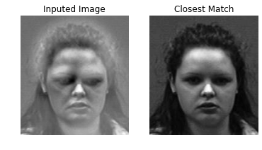

```python
show2(facialrec.Fbar[:,30],facialrec.F[:,30])
```

The mean-shifted face helps us determine the eigenfaces as shown below. This is done using Singular Value Decomposition.

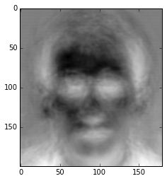

```python
show(facialrec.U[:,0])
```

### Demonstration

#### Create Sample Set of Faces

```python
def sampleFaces(n_tests, path="./faces94"):
    """Return an array containing a sample of n_tests images contained
    in the path as flattened images in the columns of the output
    """
    files = []
    for (dirpath, dirnames, filenames) in walk(path):
        for f in filenames:
            if f[-3:]=="jpg": # only get jpg images
                files.append(dirpath+"/"+f)

    #Get a sample of the images
    test_files = random.sample(files, n_tests)
    #Flatten and average the pixel values
    images = np.array([imread(f).mean(axis=2).ravel() for f in test_files]).T
    return images

test_images = sampleFaces(5)
```

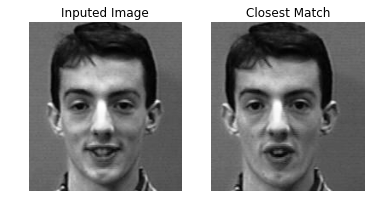

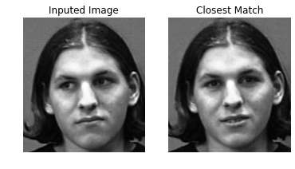

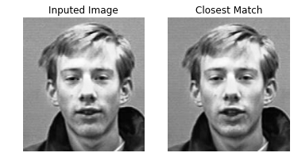

```python
img1 = sampleFaces(1)
img2 = sampleFaces(1)
img3 = sampleFaces(1)
index1 = facialrec.findNearest(img1)
index2 = facialrec.findNearest(img2)
index3 = facialrec.findNearest(img3)
show2(img1,facialrec.F[:,index1])
show2(img2,facialrec.F[:,index2])
show2(img3,facialrec.F[:,index3])
```

Note that the images are different but we were still able to find the matching face.

### end

[figure not shown]